# Course Project 1

Andrew Mendonca

July 25, 2017

## Loading and preprocessing the data

The first thing to do is unzip the file and load the data by read.csv.

```r
unzip(zipfile = "C:/Users/amend/Documents/GitHub/RepData_PeerAssessment1/activity.zip")
filedata <- read.csv("activity.csv", header = TRUE, sep = ",", na.strings = "NA",
                     colClasses = cbind("numeric", "character", "integer"))
head(filedata)
```

```
##   steps       date interval
## 1    NA 2012-10-01        0
## 2    NA 2012-10-01        5
## 3    NA 2012-10-01       10
## 4    NA 2012-10-01       15
## 5    NA 2012-10-01       20
## 6    NA 2012-10-01       25
```

The next thing to do is process/transform the data into a suitable format by correcting the dates and removing rows with missing values.

```r
filedata$date <- as.Date(filedata$date, format = "%Y-%m-%d")
filedata_ignore <- subset(filedata, !is.na(filedata$steps))
```

## What is mean total number of steps taken per day?

First, calculate the total number of steps taken per day.

```r
stepsTotal <- tapply(filedata_ignore$steps, filedata_ignore$date, sum,
                     na.rm = TRUE)
```

Next, make a histogram of the total number of steps taken per day.

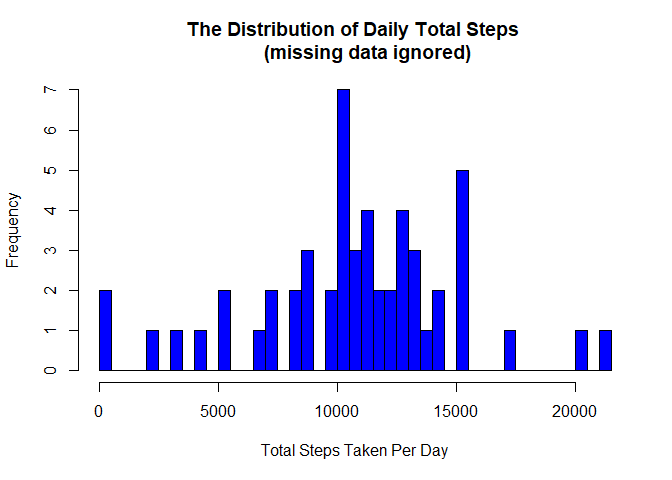

```r
hist(stepsTotal, breaks = 40, main = "The Distribution of Daily Total Steps
     (missing data ignored)", xlab = "Total Steps Taken Per Day",
     ylab = "Frequency", col = "Blue")
```

Next, calculate and report the mean and median of the total number of steps taken per day.

```r
mean(stepsTotal)
```

```
## [1] 10766.19
```

```r
median(stepsTotal)
```

```
## [1] 10765
```

Therefore, the mean is 10766 steps and the median is 10765 steps.

## What is the average daily activity pattern?

Make a time series plot (i.e. type = “l”) of the 5-minute interval (x-axis) and the average number of steps taken, averaged across all days (y-axis).

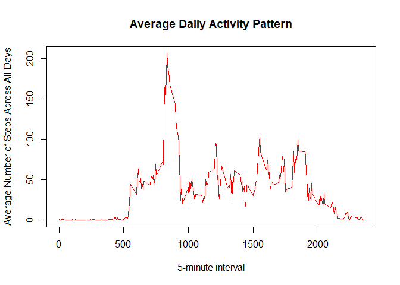

```r
average_pattern <- tapply(filedata_ignore$steps, filedata_ignore$interval,
                          mean, na.rm = TRUE)
filedata_ap <- data.frame(interval = as.integer(names(average_pattern)),
                          avg = average_pattern)
plot(filedata_ap$interval, filedata_ap$avg, type = "l", col = "Red",
     main = "Average Daily Activity Pattern", xlab = "5-minute interval",
     ylab = "Average Number of Steps Across All Days")
```

Next, determine which 5-minute interval, on average across all the days in the dataset, contains the maximum number of steps.

```r
filedata_ap[filedata_ap$avg == max(filedata_ap$avg),]
```

```
##     interval      avg
## 835      835 206.1698
```

It appears that the interval 835 contains a maximum of 206 steps.